# Estimating and visualizing meta-uncertainty with metabmc

Yuga Hikida

2023-10-28

## Introduction

This vignette provides an introduction on how to estimate and visualize posterior predictive distribution of posterior model probability and predictive mixture model using simulations with **metabmc** (**Meta**-uncertainty in **B**ayesian **M**odel **C**omparison). The packages uses **brms** and **Stan** as a backbone to enable estimation of complicated Bayesian model with simple syntax.

Given data $y$ and models $M_1,\ldots,M_J$, parameterized with $\theta$, each model’s marginal likelihood of the fixed data $y$ corresponds to:

$$p(y \mid M_j) =\int_{}^{}\,p(y \mid
\theta, M_j)\,p(\theta \mid M_j) \,d\theta$$
Using Bayes’ rule, we can compute a posterior distribution over the model indices conditional on the observed data $y$, the so-called *posterior model probabilities*:

$$\pi_j :=p(M_j \mid y)= \frac{p(y \mid
M_j) p(M_j)} {\sum_{M^{\prime} \in \mathcal{M}}p(y \mid M^{\prime})
p(M^{\prime})}$$

The posterior model probabilities (PMPs) represent the uncertainty over the choice of $J$ candidate models. However, they also have uncertainty themselves due to (i) aleatoric uncertainty in the data generating process of $y$; and (ii) finite samples to fit each model. One widely acknowledged problem in Bayesian model comparison is that PMPs obtained from data $y$ could be overconfident / underconfident.

With **metabmc**, we can obtain distribution of PMPs using simulated data $\overset{s}{y}$ given true model $M*$ and prior distribution $p(\theta)$. We currently support all the framework for three candidate models.

## Posterior distribution of model probability using **metabmc**

Suppose we have some mean-centered time series $y$ which we want to approximate with three possible candidate models:

- $M_1$ / `m1`: AR(1)
- $M_2$ / `m2`: MA(1)
- $M_3$ / `m3`: ARMA(1,1)

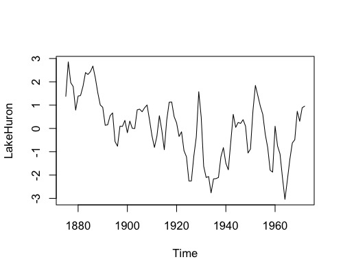

```r
plot(LakeHuron, type='l')
```

We can fit each individual model using the simple **brms** syntax:

```r
m1 <- bf(x ~ 0 + arma(p=1, q=0))
m2 <- bf(x ~ 0 + arma(p=0, q=1))
m3 <- bf(x ~ 0 + arma(p=1, q=1))

prior1 <- c(set_prior("normal(0, 0.2)", class = "ar"),
           set_prior("normal(0, 0.2)", class = "sigma"))

prior2 <- c(set_prior("normal(0, 0.2)", class = "ma"),
           set_prior("normal(0, .2)", class = "sigma"))

prior3 <- c(set_prior("normal(0, 0.2)", class = "ar"),
           set_prior("normal(0, 0.2)", class = "ma"),
           set_prior("normal(0, 0.2)", class = "sigma"))

fit1 <- brm(m1, data=LakeHuron, prior = prior1, save_pars = save_pars(all = TRUE))
fit2 <- brm(m2, data=LakeHuron, prior = prior2, save_pars = save_pars(all = TRUE))
fit3 <- brm(m3, data=LakeHuron, prior = prior3, save_pars = save_pars(all = TRUE))
```

The entire meta-uncertainty workflow is encapsulated in the one-stop-shop function `metabmc`. We input three `brmsfit` object as arguments along with other arguments which will be discussed later. Note that we need to set the argument `save_pars` in the `brm` call in order to enable `bridgesampling` later on during the process.

```r
metabmc_fit <- metabmc(fit1, fit2, fit3, n_sim=20)
```

Alternatively, you can also specify your models as a list of prior distributions and brms formulas. In this case, all models are compiled and fit inside the `metabmc` function.

```r
metabmc_fit <- metabmc(list(m1, m2, m3), list(prior1, prior2, prior3), data = LakeHuron, n_sim=3)
```

Firstly, we sample a “true model index” $M^*$ from our $J = 3$ candidates, according to the model prior $p(M)$. It is set to be uniform distribution by default indicating all models have equal probability of being sampled. If you have some prior belief about the models, here’s your chance to encode that.

Given the “true model” $M^*$, we can readily simulate synthetic data $\overset{s}{y}$ because Bayesian models are generative by definition:

$$\begin{aligned}
M^* &\sim p(M) \\
\overset{s}{\theta} & \sim p(\theta\mid M^*)\\
\overset{s}{y} & \sim p(y\mid \overset{s}{\theta}, M^*)
\end{aligned}$$

For this simulated data set $\overset{s}{y}$, we fit each model $M_1, \ldots, M_J$ to obtain a posterior $p(\theta\mid \overset{s}{y}, M_j)$ and ultimately compute the posterior model probabilities $p(M_1\mid \overset{s}{y}), p(M_2\mid \overset{s}{y}), p(M_3\mid \overset{s}{y})$. In accordance with the notation from the Meta-Uncertainty paper, we abbreviate this as:

$$\mathbf{\overset{s}{\pi}} := (p(M_1 \mid
\overset{s}{y}),\ p(M_2 \mid \overset{s}{y}),\ p(M_3 \mid
\overset{s}{y}))$$
We can repeat this process (sample true model $M^*$, sample parameters $\theta^s$, simulate data $\overset{s}{y}$, compute PMPs $\overset{s}{\pi}$) multiple times to get a whole sampling distribution of posterior model probabilities. The number of simulated data sets and computed PMPs is controlled with the `n_sim` argument, and we choose `n_sim=20` here.

Visualizations make things clearer, so here we go:

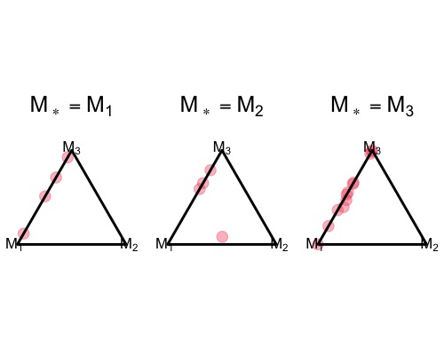

```r
plot_simulated_pmp(metabmc_fit)
```

The points in each triangle represent the simulated PMPs for data from each of the candidate models. Then, we fit a Bayesian model (**meta model**) on each of these triangles in order to capture the patterns

$p(\tilde{\pi} \mid \{\overset{s}{\pi}\}_j) = \int_{}^{} p_j(\pi \mid \tau_j) p(\tau_j \mid \{\overset{s}{\pi}\}_j) d \tau_j$

where each meta model is parameterized by $\tau_j$ and $\{\overset{s}{\pi}\}_j$ are the simulated PMPs for data originating from $M_j$.

Visualizations of estimated meta models can be obtained as follows. Note that we currently only support the logistic normal distribution, which is a more flexible alternative to the established Dirichlet distribution.

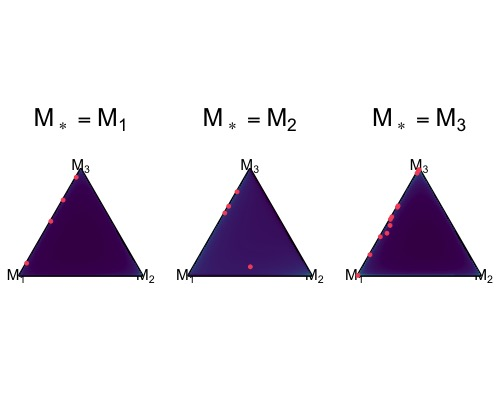

```r
plot_meta_model_density(metabmc_fit)
```

The area with high density is displayed in yellow while low density is displayed in purple.

## Predictive mixture model using **metabmc**

Combining meta models and posterior model probabilities obtained from observed data $\mathbf{\overset{o}{\pi}} := (\overset{o}{\pi_1}, \overset{o}{\pi_2}, \overset{o}{\pi_3})$, we can construct a predictive mixture distribution of posterior model probabilities by taking weighted sum of meta model by observed posterior model probabilities:

$f(\tilde{\pi}):=\sum_{j=1}^{3} \overset{o}{\pi}_j \ p(\pi \mid \{\overset{s}{\pi}\}_j)$

The visualization of estimated predictive mixture model can be obtained as follows:

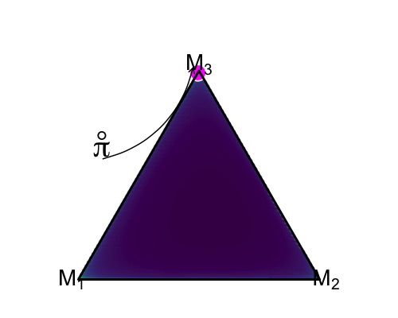

```r
plot_predictive_mixture(metabmc_fit)
```

The plot shows the predictive mixture model with the position of observed PMPs. If observed PMPs locate in the area with low density, it suggests that observed PMPs are overconfident. For our models, it does not seems to be the case, and we would expect the results to replicate.

## Reference

Schmitt, M., Radev, S. T., & Bürkner, P. C. (2023, April). Meta-Uncertainty in Bayesian Model Comparison. In International Conference on Artificial Intelligence and Statistics (pp. 11-29). PMLR.